# Transform Data

```r
library(tidyverse)
library(babynames)
library(nycflights13)

# Toy datasets to use

pollution <- tribble(
       ~city,   ~size, ~amount,
  "New York", "large",      23,
  "New York", "small",      14,
    "London", "large",      22,
    "London", "small",      16,
   "Beijing", "large",      121,
   "Beijing", "small",      56
)

band <- tribble(
   ~name,     ~band,
  "Mick",  "Stones",
  "John", "Beatles",
  "Paul", "Beatles"
)

instrument <- tribble(
    ~name,   ~plays,
   "John", "guitar",
   "Paul",   "bass",
  "Keith", "guitar"
)

instrument2 <- tribble(
    ~artist,   ~plays,
   "John", "guitar",
   "Paul",   "bass",
  "Keith", "guitar"
)
```

In the R code chunks below I have used the `head()` function as the datasets are generally large. This reduces the size of the output HTML file. The solution to the Your Turn example will not require the use of `head()`.

## babynames

```r
head(babynames)
```

| year | sex | name | n | prop |
| --- | --- | --- | --- | --- |
| 1880 | F | Mary | 7065 | 0.07238359 |
| 1880 | F | Anna | 2604 | 0.02667896 |
| 1880 | F | Emma | 2003 | 0.02052149 |
| 1880 | F | Elizabeth | 1939 | 0.01986579 |
| 1880 | F | Minnie | 1746 | 0.01788843 |
| 1880 | F | Margaret | 1578 | 0.01616720 |

## Your Turn 1

Alter the code to select just the `n` column:

```r
## Your Turn 1
select(babynames, n) %>%
  head()
```

| n |
| --- |
| 7065 |
| 2604 |
| 2003 |
| 1939 |
| 1746 |
| 1578 |

## Quiz

Which of these is NOT a way to select the `name` and `n` columns together?

```r
## Quiz
select(babynames, -c(year, sex, prop))%>%
  head()
```

| name | n |
| --- | --- |
| Mary | 7065 |
| Anna | 2604 |
| Emma | 2003 |
| Elizabeth | 1939 |
| Minnie | 1746 |
| Margaret | 1578 |

```r
select(babynames, name:n)%>%
  head()
```

| name | n |
| --- | --- |
| Mary | 7065 |
| Anna | 2604 |
| Emma | 2003 |
| Elizabeth | 1939 |
| Minnie | 1746 |
| Margaret | 1578 |

```r
select(babynames, starts_with("n"))%>%
  head()
```

| name | n |
| --- | --- |
| Mary | 7065 |
| Anna | 2604 |
| Emma | 2003 |
| Elizabeth | 1939 |
| Minnie | 1746 |
| Margaret | 1578 |

```r
# select(babynames, ends_with("n"))
```

## Your Turn 2

Show:

- All of the names where prop is greater than or equal to 0.08
- All of the children named “Sea”
- All of the names that have a missing value for `n`

```r
## Your Turn 2
filter(babynames, prop >= 0.08)%>%
  head()
```

| year | sex | name | n | prop |
| --- | --- | --- | --- | --- |
| 1880 | M | John | 9655 | 0.08154561 |
| 1880 | M | William | 9532 | 0.08050676 |
| 1881 | M | John | 8769 | 0.08098299 |

```r
filter(babynames, name == "Sea")%>%
  head()
```

| year | sex | name | n | prop |
| --- | --- | --- | --- | --- |
| 1982 | F | Sea | 5 | 2.76e-06 |
| 1985 | M | Sea | 6 | 3.12e-06 |
| 1986 | M | Sea | 5 | 2.60e-06 |
| 1998 | F | Sea | 5 | 2.58e-06 |

```r
filter(babynames, is.na(n))
```

| year | sex | name | n | prop |
| --- | --- | --- | --- | --- |

## Your Turn 3

Use Boolean operators to alter the code below to return only the rows that contain:

- Girls named Sea
- Names that were used by exactly 5 or 6 children in 1880
- Names that are one of Acura, Lexus, or Yugo

```r
## Your Turn 3
filter(babynames, name == "Sea", sex == "F")%>%
  head()
```

| year | sex | name | n | prop |
| --- | --- | --- | --- | --- |
| 1982 | F | Sea | 5 | 2.76e-06 |
| 1998 | F | Sea | 5 | 2.58e-06 |

```r
filter(babynames, n == 5 | n == 6, year == 1880)%>%
  head()
```

| year | sex | name | n | prop |
| --- | --- | --- | --- | --- |
| 1880 | F | Abby | 6 | 6.147e-05 |
| 1880 | F | Aileen | 6 | 6.147e-05 |
| 1880 | F | Alba | 6 | 6.147e-05 |
| 1880 | F | Alda | 6 | 6.147e-05 |
| 1880 | F | Alla | 6 | 6.147e-05 |
| 1880 | F | Alverta | 6 | 6.147e-05 |

```r
filter(babynames, name %in% c("Acura", "Lexus", "Yugo"))%>%
  head()
```

| year | sex | name | n | prop |
| --- | --- | --- | --- | --- |
| 1990 | F | Lexus | 36 | 1.753e-05 |
| 1990 | M | Lexus | 12 | 5.580e-06 |
| 1991 | F | Lexus | 102 | 5.017e-05 |
| 1991 | M | Lexus | 16 | 7.550e-06 |
| 1992 | F | Lexus | 193 | 9.629e-05 |
| 1992 | M | Lexus | 25 | 1.191e-05 |

## Your Turn 4

Arrange babynames by `n`. Add `prop` as a second (tie breaking) variable to arrange on. Can you tell what the smallest value of `n` is?

```r
## Your Turn 4
arrange(babynames, n, prop)%>%
  head()
```

| year | sex | name | n | prop |
| --- | --- | --- | --- | --- |
| 2007 | M | Aaban | 5 | 2.26e-06 |
| 2007 | M | Aareon | 5 | 2.26e-06 |
| 2007 | M | Aaris | 5 | 2.26e-06 |
| 2007 | M | Abd | 5 | 2.26e-06 |
| 2007 | M | Abdulazeez | 5 | 2.26e-06 |
| 2007 | M | Abdulhadi | 5 | 2.26e-06 |

## Your Turn 5

Use `desc()` to find the names with the highest prop. Then, use `desc()` to find the names with the highest n.

```r
## Your Turn 5
arrange(babynames, desc(prop))%>%
  head()
```

| year | sex | name | n | prop |
| --- | --- | --- | --- | --- |
| 1880 | M | John | 9655 | 0.08154561 |
| 1881 | M | John | 8769 | 0.08098299 |
| 1880 | M | William | 9532 | 0.08050676 |
| 1883 | M | John | 8894 | 0.07907394 |
| 1881 | M | William | 8524 | 0.07872038 |
| 1882 | M | John | 9557 | 0.07831617 |

```r
arrange(babynames, desc(n))%>%
  head()
```

| year | sex | name | n | prop |
| --- | --- | --- | --- | --- |
| 1947 | F | Linda | 99686 | 0.05483812 |
| 1948 | F | Linda | 96209 | 0.05521079 |
| 1947 | M | James | 94756 | 0.05101589 |
| 1957 | M | Michael | 92695 | 0.04237565 |
| 1947 | M | Robert | 91642 | 0.04933934 |
| 1949 | F | Linda | 91016 | 0.05184643 |

## Your Turn 6

Use `%>%` to write a sequence of functions that:

1. Filter babynames to just the girls that were born in 2015
2. Select the `name` and `n` columns
3. Arrange the results so that the most popular names are near the top.

```r
## Your Turn 6
babynames %>%
  filter(year == 2015, sex == "F") %>%
  select(name, n) %>%
  arrange(desc(n))%>%
  head()
```

| name | n |
| --- | --- |
| Emma | 20435 |
| Olivia | 19669 |
| Sophia | 17402 |
| Ava | 16361 |
| Isabella | 15594 |
| Mia | 14892 |

## Check your understanding

1. Trim `babynames` to just the rows that contain your `name` and your `sex`
2. Trim the result to just the columns that will appear in your graph (not strictly necessary, but useful practice)
3. Plot the results as a line graph with `year` on the x axis and `prop` on the y axis

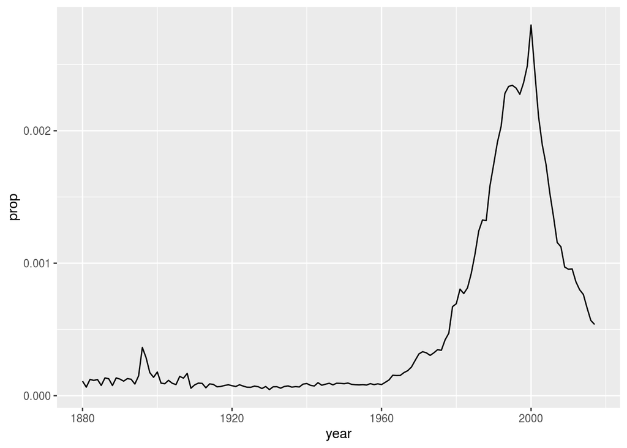

```r
## Exam
babynames %>%
  filter(name == "Garrett", sex == "M") %>%
  select(year, prop) %>%
  ggplot() +
    geom_line(mapping = aes(year, prop))
```

## Your Turn 7

Use summarise() to compute three statistics about the data:

1. The first (minimum) year in the dataset
2. The last (maximum) year in the dataset
3. The total number of children represented in the data

```r
## Your Turn 7
babynames %>%
  summarise(first = min(year),
            last = max(year),
            total = sum(n))
```

| first | last | total |
| --- | --- | --- |
| 1880 | 2017 | 348120517 |

## Your Turn 8

Extract the rows where `name == "Khaleesi"`. Then use `summarise()` and a summary functions to find:

1. The total number of children named Khaleesi
2. The first year Khaleesi appeared in the data

```r
## Your Turn 8
babynames %>%
  filter(name == "Khaleesi") %>%
  summarise(total = sum(n), first = min(year))
```

| total | first |
| --- | --- |
| 1964 | 2011 |

## Your Turn 9

Use `group_by()`, `summarise()`, and `arrange()` to display the ten most popular names. Compute popularity as the total number of children of a single gender given a name.

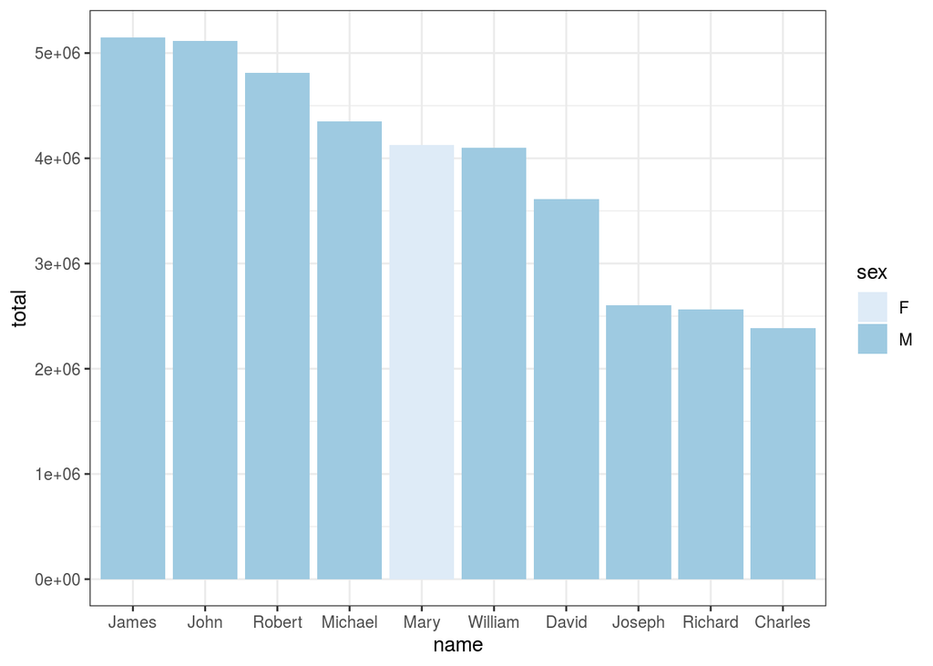

```r
## Your Turn 9
babynames %>%
  group_by(name, sex) %>%
  summarise(total = sum(n)) %>%
  arrange(desc(total)) %>%
  ungroup() %>%
  slice(1:10) %>%
  ggplot() +
    geom_col(mapping = aes(x = fct_reorder(name, desc(total)), y = total, fill = sex)) +
    theme_bw() +
    scale_fill_brewer() +
    labs(x = "name")
```

## Your Turn 10

Use grouping to calculate and then plot the number of children born each year over time.

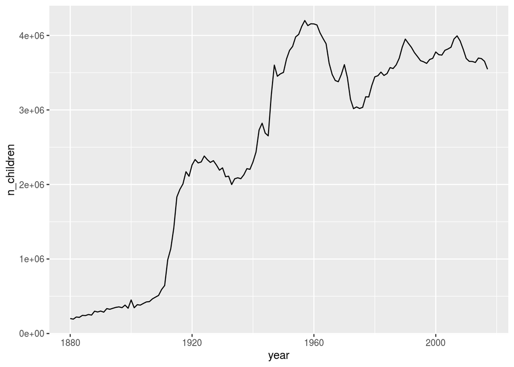

```r
## Your Turn 10
babynames %>%
  group_by(year) %>%
  summarise(n_children = sum(n)) %>%
  ggplot() +
    geom_line(mapping = aes(x = year, y = n_children))
```

## Your Turn 11

```r
## Your Turn 11
babynames %>%
  mutate(rank = min_rank(desc(prop))) %>%
  head()
```

| year | sex | name | n | prop | rank |
| --- | --- | --- | --- | --- | --- |
| 1880 | F | Mary | 7065 | 0.07238359 | 14 |
| 1880 | F | Anna | 2604 | 0.02667896 | 709 |
| 1880 | F | Emma | 2003 | 0.02052149 | 1131 |
| 1880 | F | Elizabeth | 1939 | 0.01986579 | 1192 |
| 1880 | F | Minnie | 1746 | 0.01788843 | 1427 |
| 1880 | F | Margaret | 1578 | 0.01616720 | 1683 |

## Your Turn 12

Compute each name’s rank *within its year and sex*. Then compute the median rank *for each combination of name and sex*, and arrange the results from highest median rank to lowest.

```r
## Your Turn 12
babynames %>%
  group_by(year, sex) %>%
  mutate(rank = min_rank(desc(prop))) %>%
  group_by(name, sex) %>%
  summarise(score = median(rank)) %>%
  arrange(score) %>%
  head()
```

| name | sex | score |
| --- | --- | --- |
| Mary | F | 1.0 |
| James | M | 3.0 |
| John | M | 3.0 |
| William | M | 4.0 |
| Robert | M | 6.0 |
| Michael | M | 7.5 |

```r
# babynames %>%
#   group_by(year, sex) %>%
#   mutate(rank = min_rank(desc(prop))) %>%
#   group_by(name, sex) %>%
#   summarise(score = median(rank)) %>%
#   ungroup() %>%
#   arrange(score) %>%
#   slice(1:10) %>%
#   ggplot() +
#     geom_col(mapping = aes(x = fct_reorder(name, score), y = score, fill = sex)) +
#     theme_bw() +
#     scale_fill_brewer() +
#     labs(x = "name", y = "Median Rank")
```

## Your Turn 13

Which airlines had the largest arrival delays? Complete the code below.

1. Join `airlines` to `flights`
2. Compute and order the average arrival delays by airline. Display full names, no codes.

```r
## Your Turn 13
flights %>%
  drop_na(arr_delay) %>%
  left_join(airlines, by = "carrier") %>%
  group_by(name) %>%
  summarise(delay = mean(arr_delay)) %>%
  arrange(delay)%>%
  head()
```

| name | delay |
| --- | --- |
| Alaska Airlines Inc. | -9.9308886 |
| Hawaiian Airlines Inc. | -6.9152047 |
| American Airlines Inc. | 0.3642909 |
| Delta Air Lines Inc. | 1.6443409 |
| Virgin America | 1.7644644 |
| US Airways Inc. | 2.1295951 |

## Your Turn 14

```r
## Your Turn 14
flights %>%
  drop_na(arr_delay) %>%
  left_join(airports, by = c("dest" = "faa")) %>%
  group_by(name) %>%
  summarise(distance = first(distance),
    delay = mean(arr_delay)) %>%
  arrange(desc(delay))%>%
  head()
```

| name | distance | delay |
| --- | --- | --- |
| Columbia Metropolitan | 602 | 41.76415 |
| Tulsa Intl | 1215 | 33.65986 |
| Will Rogers World | 1325 | 30.61905 |
| Jackson Hole Airport | 1874 | 28.09524 |
| Mc Ghee Tyson | 631 | 24.06920 |
| Dane Co Rgnl Truax Fld | 799 | 20.19604 |

## Appendix 1 - all code used in this training

```r
library(tidyverse)
library(babynames)
library(nycflights13)

# Toy datasets to use

pollution <- tribble(
       ~city,   ~size, ~amount,
  "New York", "large",      23,
  "New York", "small",      14,
    "London", "large",      22,
    "London", "small",      16,
   "Beijing", "large",      121,
   "Beijing", "small",      56
)

band <- tribble(
   ~name,     ~band,
  "Mick",  "Stones",
  "John", "Beatles",
  "Paul", "Beatles"
)

instrument <- tribble(
    ~name,   ~plays,
   "John", "guitar",
   "Paul",   "bass",
  "Keith", "guitar"
)

instrument2 <- tribble(
    ~artist,   ~plays,
   "John", "guitar",
   "Paul",   "bass",
  "Keith", "guitar"
)
head(babynames)

## Your Turn 1
select(babynames, n) %>%
  head()

## Quiz
select(babynames, -c(year, sex, prop))%>%
  head()
select(babynames, name:n)%>%
  head()
select(babynames, starts_with("n"))%>%
  head()
# select(babynames, ends_with("n"))

## Your Turn 2
filter(babynames, prop >= 0.08)%>%
  head()
filter(babynames, name == "Sea")%>%
  head()
filter(babynames, is.na(n))

## Your Turn 3
filter(babynames, name == "Sea", sex == "F")%>%
  head()
filter(babynames, n == 5 | n == 6, year == 1880)%>%
  head()
filter(babynames, name %in% c("Acura", "Lexus", "Yugo"))%>%
  head()

## Your Turn 4
arrange(babynames, n, prop)%>%
  head()

## Your Turn 5
arrange(babynames, desc(prop))%>%
  head()
arrange(babynames, desc(n))%>%
  head()

## Your Turn 6
babynames %>%
  filter(year == 2015, sex == "F") %>%
  select(name, n) %>%
  arrange(desc(n))%>%
  head()

## Exam
babynames %>%
  filter(name == "Garrett", sex == "M") %>%
  select(year, prop) %>%
  ggplot() +
    geom_line(mapping = aes(year, prop))

## Your Turn 7
babynames %>%
  summarise(first = min(year),
            last = max(year),
            total = sum(n))

## Your Turn 8
babynames %>%
  filter(name == "Khaleesi") %>%
  summarise(total = sum(n), first = min(year))

## Your Turn 9
babynames %>%
  group_by(name, sex) %>%
  summarise(total = sum(n)) %>%
  arrange(desc(total)) %>%
  ungroup() %>%
  slice(1:10) %>%
  ggplot() +
    geom_col(mapping = aes(x = fct_reorder(name, desc(total)), y = total, fill = sex)) +
    theme_bw() +
    scale_fill_brewer() +
    labs(x = "name")

## Your Turn 10
babynames %>%
  group_by(year) %>%
  summarise(n_children = sum(n)) %>%
  ggplot() +
    geom_line(mapping = aes(x = year, y = n_children))

## Your Turn 11
babynames %>%
  mutate(rank = min_rank(desc(prop))) %>%
  head()

## Your Turn 12
babynames %>%
  group_by(year, sex) %>%
  mutate(rank = min_rank(desc(prop))) %>%
  group_by(name, sex) %>%
  summarise(score = median(rank)) %>%
  arrange(score) %>%
  head()

# babynames %>%
#   group_by(year, sex) %>%
#   mutate(rank = min_rank(desc(prop))) %>%
#   group_by(name, sex) %>%
#   summarise(score = median(rank)) %>%
#   ungroup() %>%
#   arrange(score) %>%
#   slice(1:10) %>%
#   ggplot() +
#     geom_col(mapping = aes(x = fct_reorder(name, score), y = score, fill = sex)) +
#     theme_bw() +
#     scale_fill_brewer() +
#     labs(x = "name", y = "Median Rank")

## Your Turn 13
flights %>%
  drop_na(arr_delay) %>%
  left_join(airlines, by = "carrier") %>%
  group_by(name) %>%
  summarise(delay = mean(arr_delay)) %>%
  arrange(delay)%>%
  head()

## Your Turn 14
flights %>%
  drop_na(arr_delay) %>%
  left_join(airports, by = c("dest" = "faa")) %>%
  group_by(name) %>%
  summarise(distance = first(distance),
    delay = mean(arr_delay)) %>%
  arrange(desc(delay))%>%
  head()
```